# HW2

賴冠維

2020/10/12

## 清理資料、資料型態轉換

```r
library(dplyr)
library(magrittr)
library(ggfortify)
library(ISLR)
```

```r
Auto = read.table("C:/Users/Lai/Desktop/統計學習/Auto.data",header = T)
```

```r
for (i in 1:7) {
  Auto[,i] = as.numeric(Auto[,i])
}
for (i in 8:9) {
  Auto[,i] = as.factor(Auto[,i])
}
Auto = Auto %>% na.omit()
```

## 資料介紹

- mpg:miles per gallon
- cylinders:Number of cylinders between 4 and 8
- displacement:Engine displacement (cu. inches)
- horsepower:Engine horsepower
- weight:Vehicle weight (lbs.)
- acceleration:Time to accelerate from 0 to 60 mph (sec.)
- year:Model year (modulo 100)
- origin:Origin of car (1. American, 2. European, 3. Japanese)
- name:Vehicle name

```r
str(Auto)
```

```
## 'data.frame':    392 obs. of  9 variables:
##  $ mpg         : num  18 15 18 16 17 15 14 14 14 15 ...
##  $ cylinders   : num  8 8 8 8 8 8 8 8 8 8 ...
##  $ displacement: num  307 350 318 304 302 429 454 440 455 390 ...
##  $ horsepower  : num  130 165 150 150 140 198 220 215 225 190 ...
##  $ weight      : num  3504 3693 3436 3433 3449 ...
##  $ acceleration: num  12 11.5 11 12 10.5 10 9 8.5 10 8.5 ...
##  $ year        : num  70 70 70 70 70 70 70 70 70 70 ...
##  $ origin      : Factor w/ 3 levels "1","2","3": 1 1 1 1 1 1 1 1 1 1 ...
##  $ name        : Factor w/ 304 levels "amc ambassador brougham",..: 49 36 231 14 161 141 54 223 241 2 ...
##  - attr(*, "na.action")= 'omit' Named int [1:5] 33 127 331 337 355
##   ..- attr(*, "names")= chr [1:5] "33" "127" "331" "337" ...
```

## (8)

### (a)

- 1. 可以從個別t檢定看出，截距項及mpg皆以極趨近0的p-value(***) 拒絕虛無假設，代表此變數(horsepower)對mpg之間有關係。
- 2. 關係的強度我們可以從 Multicple R-squared : 0.6059 , Adjusted R-squared : 0.6049 這兩個值看出此線性回歸模型對mpg解釋的程度,此模型高達0.6代表解釋mpg程度尚佳。
- 3. 我們可以從horsepower項的 Estimate的值為-0.157845看出，mpg與horsepower兩者為負相關，符合我們的想像，馬力大的車通常較耗油。

```r
rg = lm(mpg~horsepower,data = Auto)
summary(rg)
```

```
##
## Call:
## lm(formula = mpg ~ horsepower, data = Auto)
##
## Residuals:
##      Min       1Q   Median       3Q      Max
## -13.5710  -3.2592  -0.3435   2.7630  16.9240
##
## Coefficients:
##              Estimate Std. Error t value Pr(>|t|)
## (Intercept) 39.935861   0.717499   55.66   <2e-16 ***
## horsepower  -0.157845   0.006446  -24.49   <2e-16 ***
## ---
## Signif. codes:  0 '***' 0.001 '**' 0.01 '*' 0.05 '.' 0.1 ' ' 1
##
## Residual standard error: 4.906 on 390 degrees of freedom
## Multiple R-squared:  0.6059, Adjusted R-squared:  0.6049
## F-statistic: 599.7 on 1 and 390 DF,  p-value: < 2.2e-16
```

- 4. 使用predict()預設之信賴區間即為95%的信賴區間，其預測值為24.46708，而預測區間與信賴區間相比多了一個標準差，因此Intervals的區間更寬  
     因為預測區間為估計一個“個別值”，而信賴區間為估計一個“平均值”，因此有此結果。

```r
predict(rg,data.frame(horsepower = 98),interval = "confidence")
```

```
##        fit      lwr      upr
## 1 24.46708 23.97308 24.96108
```

```r
predict(rg,data.frame(horsepower = 98),interval = "prediction")
```

```
##        fit     lwr      upr
## 1 24.46708 14.8094 34.12476
```

### (b)

- 兩者呈現負相關，與我們的直覺相同，馬力大的車油耗較差。

```r
attach(Auto)
```

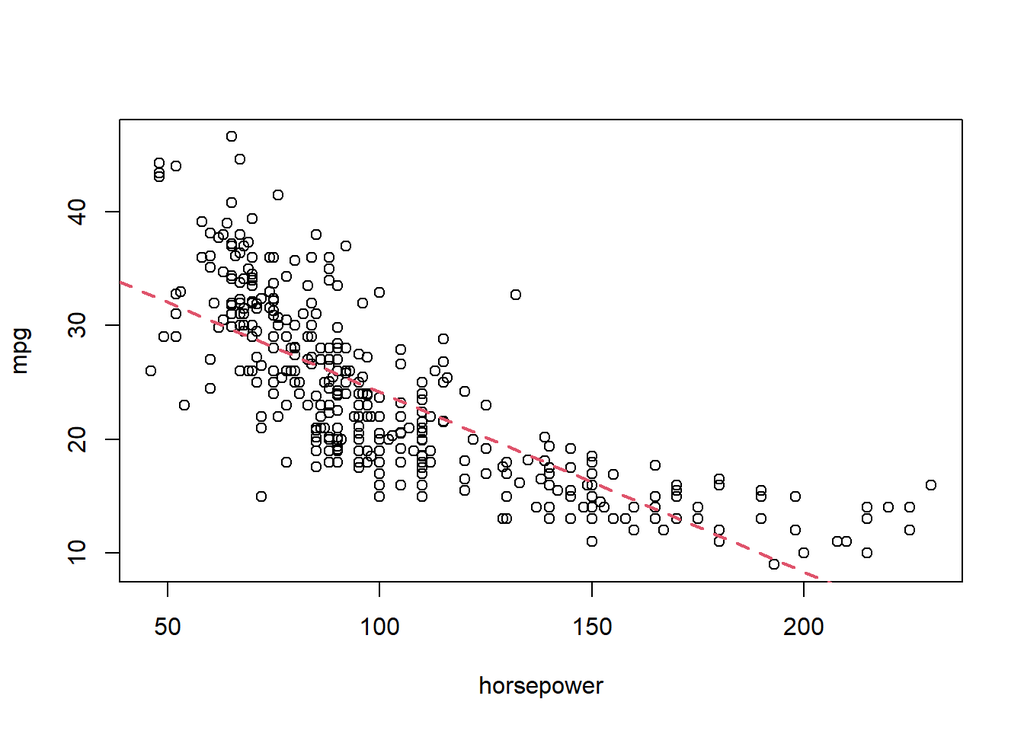

```r
plot(horsepower,mpg)
abline(rg,col = 2, lwd = 2,lty = 2)
```

### (c)

- 由下圖可看見以下幾個結果：
- 1. 殘差不隨機，有趨勢，代表解釋變數並未能對mpg有效解釋。
- 2. Normal Q-Q圖可看出，殘差偏離斜直線代表殘差為不對襯分布，與我們通常對殘差的常態假設不符。
- 3. 而從Leverage圖可看出，哪些觀測值偏離回歸線甚遠，可能造成回歸線預測偏離。

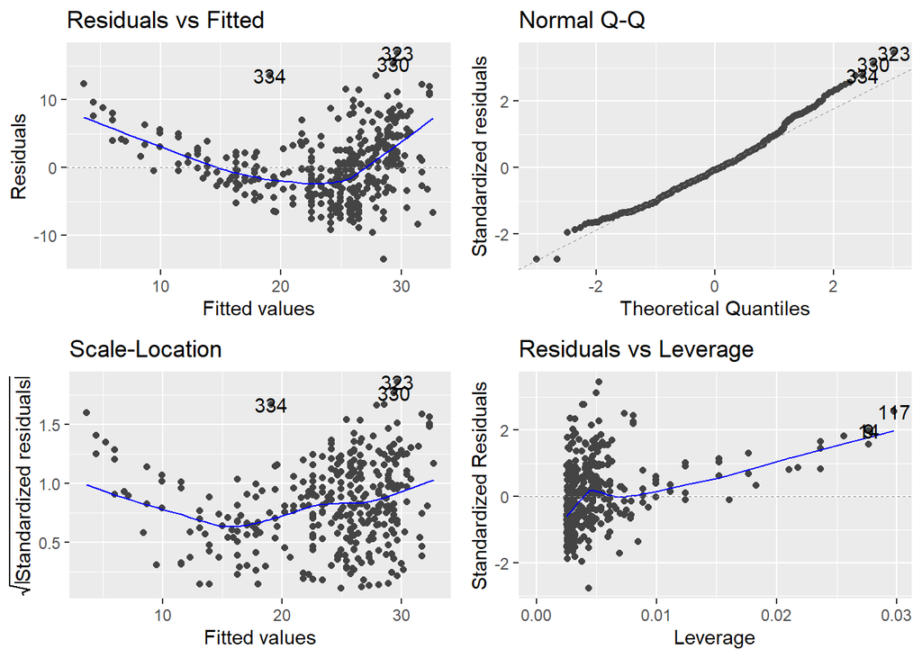

```r
autoplot(rg)
```

## (9)

### (a)

- 從散佈圖可看出，displacement、horsepower、weight對mpg呈現負相關，year對mpg為正相關，其代表：
- 引擎排氣量(displacement)越高，油耗越差。
- 馬力(horsepower)越高，油耗越差。
- 汽車重量(weight)越重，油耗越差。

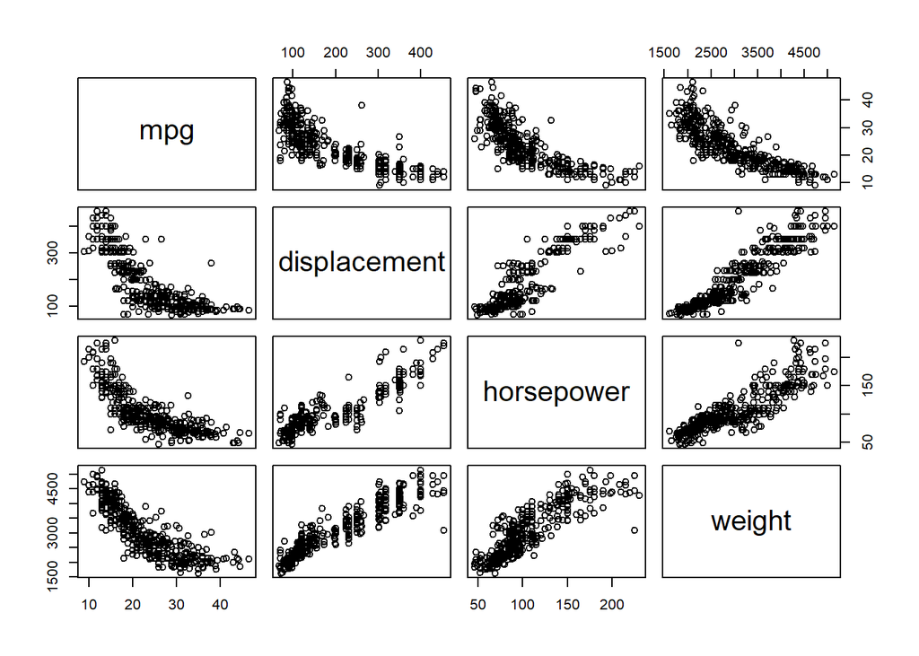

```r
x = Auto %>% select(mpg,displacement,horsepower,weight)
pairs(x)
```

- 可以看出來當汽缸(cylinders)變多，mpg顯著下降，與我們的想法相符，汽缸數較多的車代表排氣量較高，因此油耗較高，而地區(origin)並未有太顯著的差別。

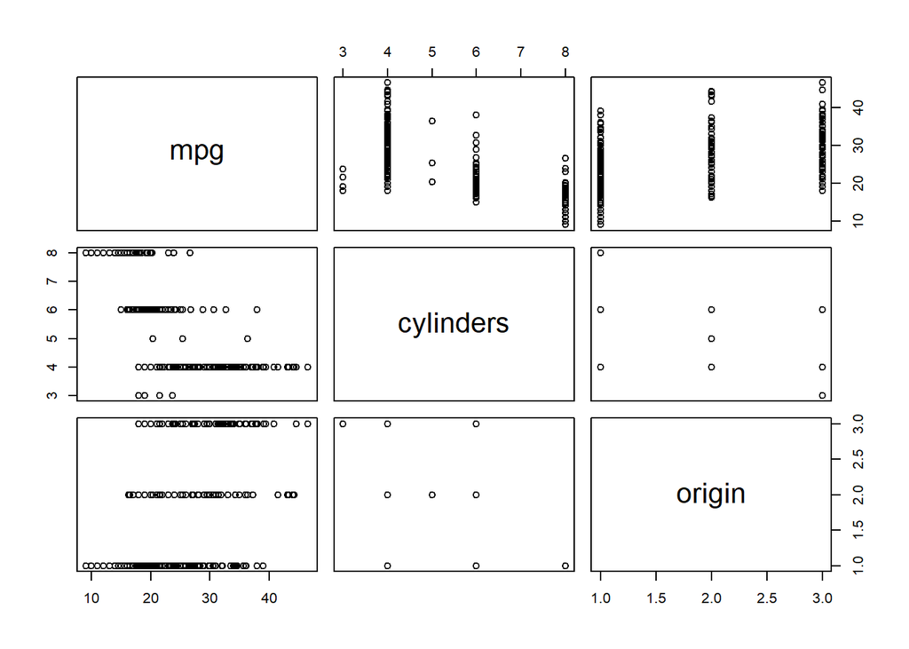

```r
x = Auto %>% select(mpg,cylinders,origin)
pairs(x)
```

### (b)

- 從此相關係數的表可見與上述散佈圖的結果相同。

```r
cor(Auto[1:7])
```

```
##                     mpg  cylinders displacement horsepower     weight
## mpg           1.0000000 -0.7776175   -0.8051269 -0.7784268 -0.8322442
## cylinders    -0.7776175  1.0000000    0.9508233  0.8429834  0.8975273
## displacement -0.8051269  0.9508233    1.0000000  0.8972570  0.9329944
## horsepower   -0.7784268  0.8429834    0.8972570  1.0000000  0.8645377
## weight       -0.8322442  0.8975273    0.9329944  0.8645377  1.0000000
## acceleration  0.4233285 -0.5046834   -0.5438005 -0.6891955 -0.4168392
## year          0.5805410 -0.3456474   -0.3698552 -0.4163615 -0.3091199
##              acceleration       year
## mpg             0.4233285  0.5805410
## cylinders      -0.5046834 -0.3456474
## displacement   -0.5438005 -0.3698552
## horsepower     -0.6891955 -0.4163615
## weight         -0.4168392 -0.3091199
## acceleration    1.0000000  0.2903161
## year            0.2903161  1.0000000
```

### (c)

- 係數中displacement、weight、year、origin為顯著通過個別t檢定，而此處可見origin為顯著，在上述的分析中並未看到此變數對mpg有顯著的解釋能力，但在此卻顯著，也代表origin可能提供別的邊際貢獻。

```r
mrg = lm(mpg~.-name,data = Auto)
summary(mrg)
```

```
##
## Call:
## lm(formula = mpg ~ . - name, data = Auto)
##
## Residuals:
##     Min      1Q  Median      3Q     Max
## -9.0095 -2.0785 -0.0982  1.9856 13.3608
##
## Coefficients:
##                Estimate Std. Error t value Pr(>|t|)
## (Intercept)  -1.795e+01  4.677e+00  -3.839 0.000145 ***
## cylinders    -4.897e-01  3.212e-01  -1.524 0.128215
## displacement  2.398e-02  7.653e-03   3.133 0.001863 **
## horsepower   -1.818e-02  1.371e-02  -1.326 0.185488
## weight       -6.710e-03  6.551e-04 -10.243  < 2e-16 ***
## acceleration  7.910e-02  9.822e-02   0.805 0.421101
## year          7.770e-01  5.178e-02  15.005  < 2e-16 ***
## origin2       2.630e+00  5.664e-01   4.643 4.72e-06 ***
## origin3       2.853e+00  5.527e-01   5.162 3.93e-07 ***
## ---
## Signif. codes:  0 '***' 0.001 '**' 0.01 '*' 0.05 '.' 0.1 ' ' 1
##
## Residual standard error: 3.307 on 383 degrees of freedom
## Multiple R-squared:  0.8242, Adjusted R-squared:  0.8205
## F-statistic: 224.5 on 8 and 383 DF,  p-value: < 2.2e-16
```

### (d)

- 由下圖可看見以下幾個結果：
- 1. 殘差不隨機，有趨勢，代表解釋變數並未能對mpg有效解釋。
- 2. Normal Q-Q圖可看出，殘差偏離斜直線代表殘差為不對襯分布，與我們通常對殘差的常態假設不符。
- 3. 而從Leverage圖可看出，哪些觀測值偏離回歸線甚遠，可能造成回歸線預測偏離，標記出第327,394,14筆資料可能為不正常的離群值，而明顯可見第14筆觀測值存在有高度的Leverage Effects。

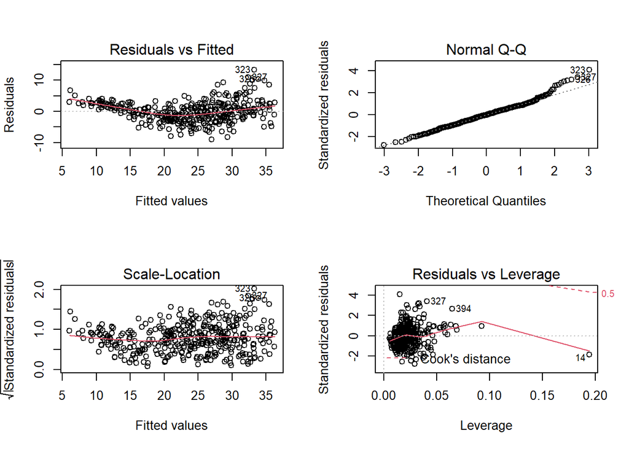

```r
par(mfrow=c(2,2))
plot(mrg)
```

- 由下面結果可見，此車種的汽缸數(cylinders)、引擎排量(displacement)、馬力(horsepower)明顯高於平均，但重量(weight)卻與平均差不多，而油耗(mpg)卻明顯差很多 ，可能是因為weight的部分其他觀測值有明顯的差異。

```r
Auto[14,"name"]
```

```
## [1] buick estate wagon (sw)
## 304 Levels: amc ambassador brougham amc ambassador dpl ... vw rabbit custom
```

```r
paste("Average mpg:",mean(Auto$mpg),"Buick Estate Wagon:",Auto[14,"mpg"])
```

```
## [1] "Average mpg: 23.4459183673469 Buick Estate Wagon: 14"
```

```r
paste("Average cylinders:",mean(Auto$cylinders),"Buick Estate Wagon:",Auto[14,"cylinders"])
```

```
## [1] "Average cylinders: 5.4719387755102 Buick Estate Wagon: 8"
```

```r
paste("Average displacement:",mean(Auto$displacement),"Buick Estate Wagon:",Auto[14,"displacement"])
```

```
## [1] "Average displacement: 194.411989795918 Buick Estate Wagon: 455"
```

```r
paste("Average horsepower:",mean(Auto$horsepower),"Buick Estate Wagon:",Auto[14,"horsepower"])
```

```
## [1] "Average horsepower: 104.469387755102 Buick Estate Wagon: 225"
```

```r
paste("Average weight:",mean(Auto$weight),"Buick Estate Wagon:",Auto[14,"weight"])
```

```
## [1] "Average weight: 2977.58418367347 Buick Estate Wagon: 3086"
```

```r
paste("Average year:",mean(Auto$year),"Buick Estate Wagon:",Auto[14,"year"])
```

```
## [1] "Average year: 75.9795918367347 Buick Estate Wagon: 70"
```

### (e)

- 從上述散佈圖可發現weight、cylinders及weight、displacement之間有高度相關，可能存在有共線性的問題，這時候加入交互項來解決此問題，從表1、表2皆可看到交互項通過個別t檢定，拒絕虛無假設，對mpg有顯著的解釋能力。

```r
mrg1 = lm(mpg~weight*cylinders,data = Auto)
summary(mrg1)
```

```
##
## Call:
## lm(formula = mpg ~ weight * cylinders, data = Auto)
##
## Residuals:
##      Min       1Q   Median       3Q      Max
## -14.4916  -2.6225  -0.3927   1.7794  16.7087
##
## Coefficients:
##                    Estimate Std. Error t value Pr(>|t|)
## (Intercept)      65.3864559  3.7333137  17.514  < 2e-16 ***
## weight           -0.0128348  0.0013628  -9.418  < 2e-16 ***
## cylinders        -4.2097950  0.7238315  -5.816 1.26e-08 ***
## weight:cylinders  0.0010979  0.0002101   5.226 2.83e-07 ***
## ---
## Signif. codes:  0 '***' 0.001 '**' 0.01 '*' 0.05 '.' 0.1 ' ' 1
##
## Residual standard error: 4.165 on 388 degrees of freedom
## Multiple R-squared:  0.7174, Adjusted R-squared:  0.7152
## F-statistic: 328.3 on 3 and 388 DF,  p-value: < 2.2e-16
```

```r
mrg2 = lm(mpg~weight*displacement,data = Auto)
summary(mrg2)
```

```
##
## Call:
## lm(formula = mpg ~ weight * displacement, data = Auto)
##
## Residuals:
##      Min       1Q   Median       3Q      Max
## -13.8664  -2.4801  -0.3355   1.8071  17.9429
##
## Coefficients:
##                       Estimate Std. Error t value Pr(>|t|)
## (Intercept)          5.372e+01  1.940e+00  27.697  < 2e-16 ***
## weight              -8.931e-03  8.474e-04 -10.539  < 2e-16 ***
## displacement        -7.831e-02  1.131e-02  -6.922 1.85e-11 ***
## weight:displacement  1.744e-05  2.789e-06   6.253 1.06e-09 ***
## ---
## Signif. codes:  0 '***' 0.001 '**' 0.01 '*' 0.05 '.' 0.1 ' ' 1
##
## Residual standard error: 4.097 on 388 degrees of freedom
## Multiple R-squared:  0.7265, Adjusted R-squared:  0.7244
## F-statistic: 343.6 on 3 and 388 DF,  p-value: < 2.2e-16
```

- ’:’代表單獨放交互項，此處放displacement與cylinders的交互項，結果如下表，顯著拒絕虛無假設，對mpg有解釋能力。

```r
mrg3 = lm(mpg~displacement:cylinders,data = Auto)
summary(mrg3)
```

```
##
## Call:
## lm(formula = mpg ~ displacement:cylinders, data = Auto)
##
## Residuals:
##     Min      1Q  Median      3Q     Max
## -11.705  -3.426  -0.450   2.704  17.715
##
## Coefficients:
##                          Estimate Std. Error t value Pr(>|t|)
## (Intercept)            30.9896203  0.3905111   79.36   <2e-16 ***
## displacement:cylinders -0.0061177  0.0002462  -24.85   <2e-16 ***
## ---
## Signif. codes:  0 '***' 0.001 '**' 0.01 '*' 0.05 '.' 0.1 ' ' 1
##
## Residual standard error: 4.863 on 390 degrees of freedom
## Multiple R-squared:  0.6128, Adjusted R-squared:  0.6119
## F-statistic: 617.4 on 1 and 390 DF,  p-value: < 2.2e-16
```

### (f)

- 上述說到殘差具有趨勢，可由加入平方項、根號項、log項等方式解決此問題， 表1為mpg對所有變數並加入平方項後的結果，再剔除掉不顯著的變數後得到表2。
- 由診斷圖可見，殘差的趨勢、Leverage的趨勢皆被消除，代表加入此平方項有顯著的效果。

```r
mrg4 = lm(mpg~.- name + I(weight^2),data = Auto)

mrg5 = lm(mpg~.- name
          - acceleration
          - cylinders
          + I(weight^2),data = Auto)

summary(mrg4)
```

```
##
## Call:
## lm(formula = mpg ~ . - name + I(weight^2), data = Auto)
##
## Residuals:
##     Min      1Q  Median      3Q     Max
## -8.9387 -1.6686 -0.1062  1.7273 12.8215
##
## Coefficients:
##                Estimate Std. Error t value Pr(>|t|)
## (Intercept)   1.291e-01  4.613e+00   0.028  0.97768
## cylinders    -2.819e-01  2.898e-01  -0.973  0.33118
## displacement  1.750e-02  6.917e-03   2.529  0.01183 *
## horsepower   -2.543e-02  1.235e-02  -2.059  0.04019 *
## weight       -2.062e-02  1.570e-03 -13.134  < 2e-16 ***
## acceleration  6.445e-02  8.836e-02   0.729  0.46623
## year          8.236e-01  4.683e-02  17.586  < 2e-16 ***
## origin2       1.850e+00  5.160e-01   3.585  0.00038 ***
## origin3       1.493e+00  5.172e-01   2.886  0.00412 **
## I(weight^2)   2.224e-06  2.326e-07   9.559  < 2e-16 ***
## ---
## Signif. codes:  0 '***' 0.001 '**' 0.01 '*' 0.05 '.' 0.1 ' ' 1
##
## Residual standard error: 2.974 on 382 degrees of freedom
## Multiple R-squared:  0.8581, Adjusted R-squared:  0.8548
## F-statistic: 256.7 on 9 and 382 DF,  p-value: < 2.2e-16
```

```r
summary(mrg5)
```

```
##
## Call:
## lm(formula = mpg ~ . - name - acceleration - cylinders + I(weight^2),
##     data = Auto)
##
## Residuals:
##     Min      1Q  Median      3Q     Max
## -8.9157 -1.6289 -0.0723  1.6161 12.8276
##
## Coefficients:
##                Estimate Std. Error t value Pr(>|t|)
## (Intercept)   9.401e-01  4.192e+00   0.224 0.822685
## displacement  1.242e-02  5.181e-03   2.397 0.016987 *
## horsepower   -2.991e-02  9.653e-03  -3.099 0.002084 **
## weight       -2.061e-02  1.539e-03 -13.392  < 2e-16 ***
## year          8.221e-01  4.667e-02  17.614  < 2e-16 ***
## origin2       1.824e+00  5.149e-01   3.542 0.000445 ***
## origin3       1.434e+00  5.134e-01   2.793 0.005478 **
## I(weight^2)   2.244e-06  2.318e-07   9.683  < 2e-16 ***
## ---
## Signif. codes:  0 '***' 0.001 '**' 0.01 '*' 0.05 '.' 0.1 ' ' 1
##
## Residual standard error: 2.972 on 384 degrees of freedom
## Multiple R-squared:  0.8576, Adjusted R-squared:  0.855
## F-statistic: 330.3 on 7 and 384 DF,  p-value: < 2.2e-16
```

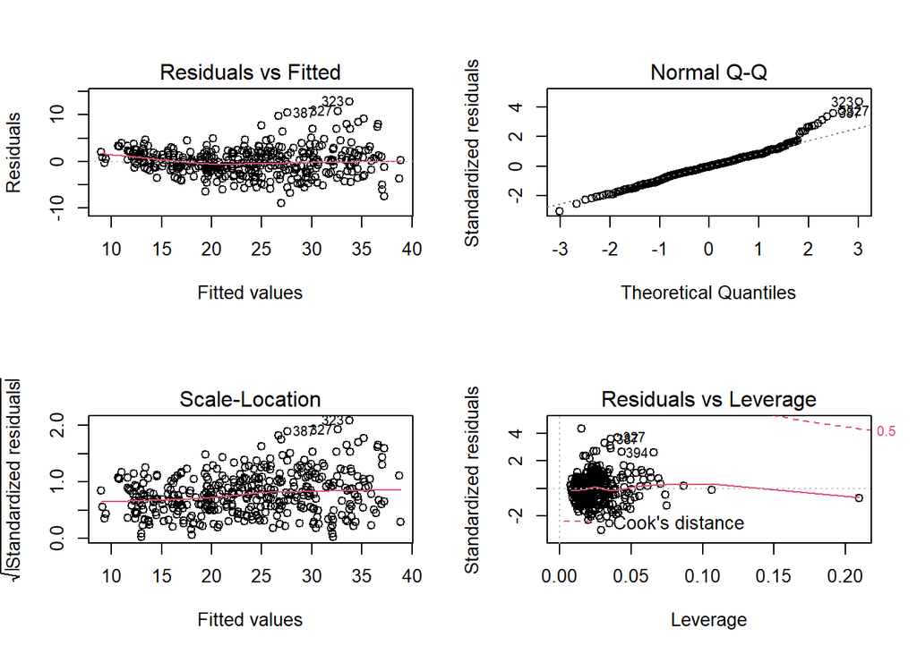

```r
par(mfrow=c(2,2))
plot(mrg4)
```

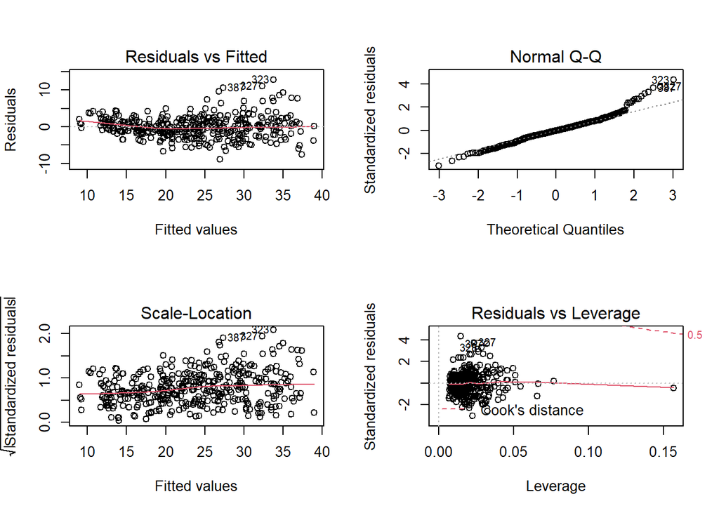

```r
plot(mrg5)
```

## 10

### (a)

Carseats為關於兒童車用座椅的資料，400筆觀測值代表不同店家，共有11個變數，變數敘述如下：

- Sales:Unit sales (in thousands) at each location
- CompPrice:Price charged by competitor at each location
- Income:Community income level (in thousands of dollars)
- Advertising:Local advertising budget for company at each location (in thousands of dollars)
- Population:Population size in region (in thousands)
- Price:Price company charges for car seats at each site
- ShelveLoc:A factor with levels Bad, Good and Medium indicating the quality of the shelving location for the car seats at each site
- Age:Average age of the local population
- Education:Education level at each location
- Urban:A factor with levels No and Yes to indicate whether the store is in an urban or rural location
- US:A factor with levels No and Yes to indicate whether the store is in the US or not
- Urban 為binary的變數，代表店家是否在都會區，未通過個別t檢定。
- 整體模型的R squared僅0.2393，代表此模型表現欠佳，尚有許多變異未解釋，有改進的空間。

```r
library(ISLR)
data("Carseats")

fit = lm(Sales~Price+Urban+US,data = Carseats )
summary(fit)
```

```
##
## Call:
## lm(formula = Sales ~ Price + Urban + US, data = Carseats)
##
## Residuals:
##     Min      1Q  Median      3Q     Max
## -6.9206 -1.6220 -0.0564  1.5786  7.0581
##
## Coefficients:
##              Estimate Std. Error t value Pr(>|t|)
## (Intercept) 13.043469   0.651012  20.036  < 2e-16 ***
## Price       -0.054459   0.005242 -10.389  < 2e-16 ***
## UrbanYes    -0.021916   0.271650  -0.081    0.936
## USYes        1.200573   0.259042   4.635 4.86e-06 ***
## ---
## Signif. codes:  0 '***' 0.001 '**' 0.01 '*' 0.05 '.' 0.1 ' ' 1
##
## Residual standard error: 2.472 on 396 degrees of freedom
## Multiple R-squared:  0.2393, Adjusted R-squared:  0.2335
## F-statistic: 41.52 on 3 and 396 DF,  p-value: < 2.2e-16
```

### (b)

```r
index = sapply(1:11,function(x){
  is.numeric(Carseats[,x])
  }
)
Carseats[,index] %<>% scale()


print(fit)
```

```
##
## Call:
## lm(formula = Sales ~ Price + Urban + US, data = Carseats)
##
## Coefficients:
## (Intercept)        Price     UrbanYes        USYes
##    13.04347     -0.05446     -0.02192      1.20057
```

### (c)

模型中有兩個Binary變數，依這兩個變數的結果共有以下四種情況，如下：

- 當Urban、US皆為Yes
  $$(Status1):Sales = 13.04347 -0.05446*Price - 0.02192*Urban_{Yes} + 1.20057*US_{Yes}$$
- Urban 為Yes，US為NO
  $$(Status1): Sales = 13.04347-0.05446*Price - 0.02192*Urban_{Yes}$$
- Urban為NO，US為YES
  $$(Status1): Sales =13.04347 -0.05446*Price + 1.20057*US_{Yes}$$
- Urban、US皆為NO
  $$(Status1): Sales = 13.04347-0.05446*Price$$

### (d)

- 回歸放入全部的變數，發現Population、Education、Urban、US皆未通過個別t檢定，其餘變數皆通過個別t檢定，拒絕虛無假設。

```r
fit1 = lm(Sales~.,data = Carseats)
summary(fit1)
```

```
##
## Call:
## lm(formula = Sales ~ ., data = Carseats)
##
## Residuals:
##      Min       1Q   Median       3Q      Max
## -1.01598 -0.24463  0.00748  0.23496  1.20797
##
## Coefficients:
##                 Estimate Std. Error t value Pr(>|t|)
## (Intercept)     -0.73292    0.05999 -12.217  < 2e-16 ***
## CompPrice        0.50397    0.02252  22.378  < 2e-16 ***
## Income           0.15660    0.01828   8.565 2.58e-16 ***
## Advertising      0.28987    0.02619  11.066  < 2e-16 ***
## Population       0.01085    0.01933   0.561    0.575
## Price           -0.79946    0.02239 -35.700  < 2e-16 ***
## ShelveLocGood    1.71742    0.05422  31.678  < 2e-16 ***
## ShelveLocMedium  0.69286    0.04465  15.516  < 2e-16 ***
## Age             -0.26413    0.01825 -14.472  < 2e-16 ***
## Education       -0.01958    0.01830  -1.070    0.285
## UrbanYes         0.04351    0.04000   1.088    0.277
## USYes           -0.06519    0.05306  -1.229    0.220
## ---
## Signif. codes:  0 '***' 0.001 '**' 0.01 '*' 0.05 '.' 0.1 ' ' 1
##
## Residual standard error: 0.3608 on 388 degrees of freedom
## Multiple R-squared:  0.8734, Adjusted R-squared:  0.8698
## F-statistic: 243.4 on 11 and 388 DF,  p-value: < 2.2e-16
```

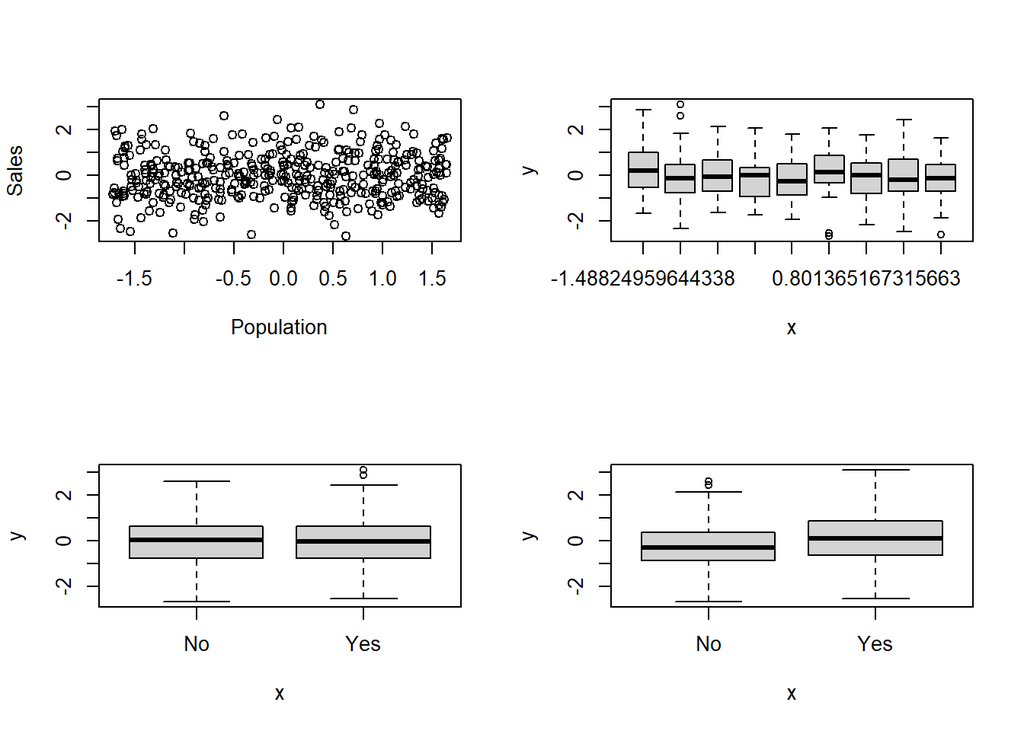

```r
attach(Carseats)

par(mfrow=c(2,2))
plot(Population,Sales)
plot(as.factor(Education),Sales)
plot(Urban,Sales)
plot(US,Sales)
```

## (e)

- 發現去掉上述4個個別t檢定未通過的變數後，R Square並未有明顯的下降，而自由度卻有大幅的上升。
- 此舉動代表降低了估計參數的同時並未犧牲掉解釋力，故此篩選變數是一個好的選擇。

```r
fit1 = lm(Sales~.-Population-Education-Urban-US,data = Carseats)
summary(fit1)
```

```
##
## Call:
## lm(formula = Sales ~ . - Population - Education - Urban - US,
##     data = Carseats)
##
## Residuals:
##      Min       1Q   Median       3Q      Max
## -0.98184 -0.24624  0.00997  0.23839  1.17885
##
## Coefficients:
##                 Estimate Std. Error t value Pr(>|t|)
## (Intercept)     -0.74228    0.03699  -20.07   <2e-16 ***
## CompPrice        0.50265    0.02239   22.45   <2e-16 ***
## Income           0.15642    0.01821    8.59   <2e-16 ***
## Advertising      0.27294    0.01819   15.01   <2e-16 ***
## Price           -0.79913    0.02239  -35.70   <2e-16 ***
## ShelveLocGood    1.71228    0.05400   31.71   <2e-16 ***
## ShelveLocMedium  0.69119    0.04439   15.57   <2e-16 ***
## Age             -0.26461    0.01822  -14.52   <2e-16 ***
## ---
## Signif. codes:  0 '***' 0.001 '**' 0.01 '*' 0.05 '.' 0.1 ' ' 1
##
## Residual standard error: 0.361 on 392 degrees of freedom
## Multiple R-squared:  0.872,  Adjusted R-squared:  0.8697
## F-statistic: 381.4 on 7 and 392 DF,  p-value: < 2.2e-16
```

## (f)

- 我們可由兩模型的R Square 及 fit.values對實際Sales的plot來看，明顯可以發現(e)小題模型的解釋力比較好，從圖也可以發現預測的誤差較小。

```r
summary(fit)
```

```
##
## Call:
## lm(formula = Sales ~ Price + Urban + US, data = Carseats)
##
## Residuals:
##     Min      1Q  Median      3Q     Max
## -6.9206 -1.6220 -0.0564  1.5786  7.0581
##
## Coefficients:
##              Estimate Std. Error t value Pr(>|t|)
## (Intercept) 13.043469   0.651012  20.036  < 2e-16 ***
## Price       -0.054459   0.005242 -10.389  < 2e-16 ***
## UrbanYes    -0.021916   0.271650  -0.081    0.936
## USYes        1.200573   0.259042   4.635 4.86e-06 ***
## ---
## Signif. codes:  0 '***' 0.001 '**' 0.01 '*' 0.05 '.' 0.1 ' ' 1
##
## Residual standard error: 2.472 on 396 degrees of freedom
## Multiple R-squared:  0.2393, Adjusted R-squared:  0.2335
## F-statistic: 41.52 on 3 and 396 DF,  p-value: < 2.2e-16
```

```r
summary(fit1)
```

```
##
## Call:
## lm(formula = Sales ~ . - Population - Education - Urban - US,
##     data = Carseats)
##
## Residuals:
##      Min       1Q   Median       3Q      Max
## -0.98184 -0.24624  0.00997  0.23839  1.17885
##
## Coefficients:
##                 Estimate Std. Error t value Pr(>|t|)
## (Intercept)     -0.74228    0.03699  -20.07   <2e-16 ***
## CompPrice        0.50265    0.02239   22.45   <2e-16 ***
## Income           0.15642    0.01821    8.59   <2e-16 ***
## Advertising      0.27294    0.01819   15.01   <2e-16 ***
## Price           -0.79913    0.02239  -35.70   <2e-16 ***
## ShelveLocGood    1.71228    0.05400   31.71   <2e-16 ***
## ShelveLocMedium  0.69119    0.04439   15.57   <2e-16 ***
## Age             -0.26461    0.01822  -14.52   <2e-16 ***
## ---
## Signif. codes:  0 '***' 0.001 '**' 0.01 '*' 0.05 '.' 0.1 ' ' 1
##
## Residual standard error: 0.361 on 392 degrees of freedom
## Multiple R-squared:  0.872,  Adjusted R-squared:  0.8697
## F-statistic: 381.4 on 7 and 392 DF,  p-value: < 2.2e-16
```

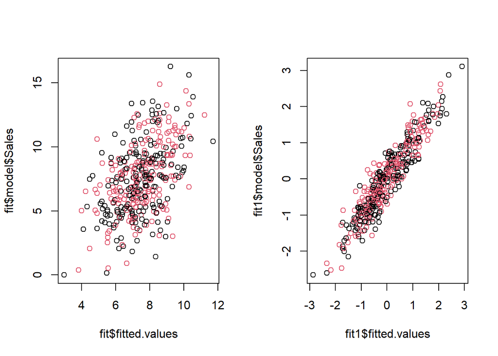

```r
par(mfrow=c(1,2))
plot(fit$fitted.values,fit$model$Sales,col=1:2)
plot(fit1$fitted.values,fit1$model$Sales,col=1:2)
```

## (g)

- 可以看到(e)小題的模型的信賴區間都未包括0，皆顯著

```r
confint(fit1)
```

```
##                      2.5 %     97.5 %
## (Intercept)     -0.8150011 -0.6695679
## CompPrice        0.4586319  0.5466658
## Income           0.1206214  0.1922261
## Advertising      0.2371770  0.3086930
## Price           -0.8431403 -0.7551195
## ShelveLocGood    1.6061162  1.8184431
## ShelveLocMedium  0.6039064  0.7784684
## Age             -0.3004333 -0.2287799
```

## (h)

- (e)小題的模型所畫出的Residuals vs Leverage Plot中,存在有幾個殘差較大的觀測值，但其Cook Distance並未超過0.5，皆包含在裡面，因此認為此模型中並未有存在High Leverage的觀測值。
- 而第208,298筆資料其Residuals接近+-3，而由Scale-Location Plot 圖中也可發現， 標準化後的Residuals也超過1.5，因此可能為Outliers，但仍需要再加以分析才決定是否要加以刪除。

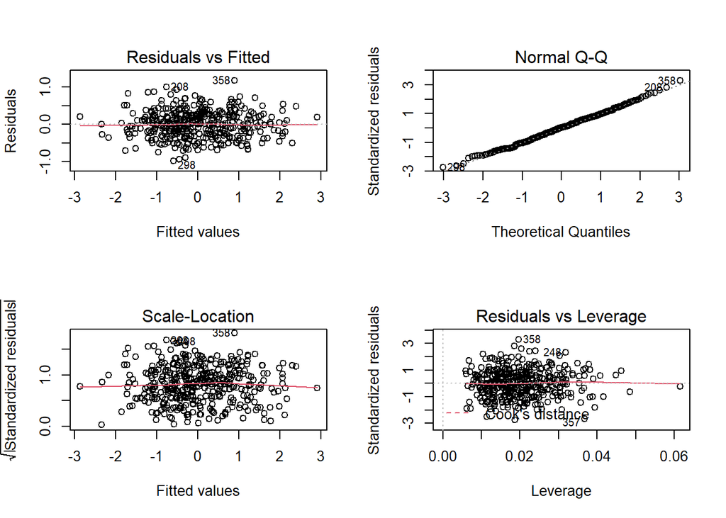

```r
par(mfrow=c(2,2))
plot(fit1)
```